# Part I - (Loan Data from Prosper)

## Bivariate Exploration

```python
def bivariateBar(variable, hueVar):
    plt.figure(figsize = [12, 6])
    sb.countplot(data=df, x=variable, hue=hueVar);
    plt.show()
def bivariateBar_II(variable, hueVar):
    plt.figure(figsize = [12, 6])
    sb.countplot(data=df, x=variable, hue=hueVar);
    variable= variable.replace("_"," ") # replace _ with space
    plt.show()
```

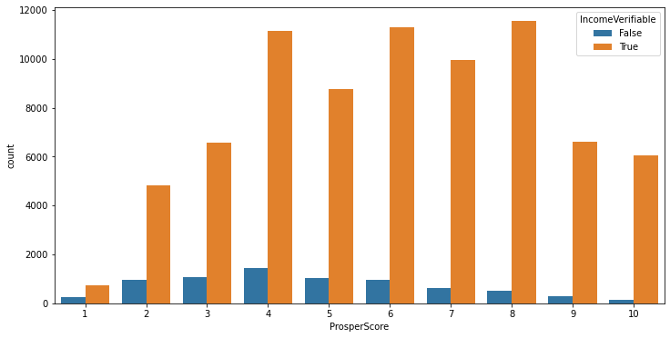

```python
#Does IncomeVerifiable have significant effect on ProsperScore?
bivariateBar('ProsperScore','IncomeVerifiable');
```

**Seen above in the plotted graph, those with verifiable income have high ProsperScore**

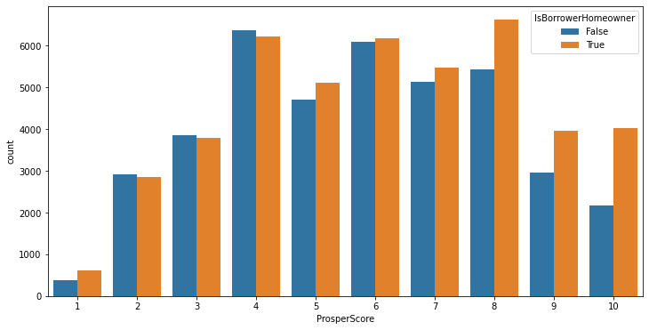

```python
#Do borrowers who are home owners have high ProsperScore?
bivariateBar('ProsperScore','IsBorrowerHomeowner');
```

**It can be seen from the above graph that the ProsperScore of borrowers who are home owners is higher than those who are not.**

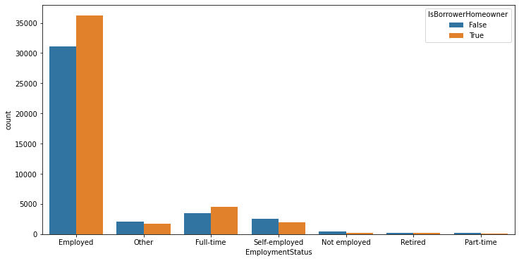

```python
# verify if those that are employed are home owners
bivariateBar_II('EmploymentStatus','IsBorrowerHomeowner');
```

**The above graph shows that most of the people that are employed are home ownwers**

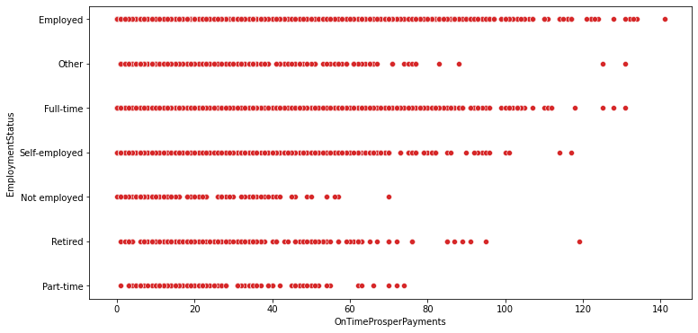

```python
# PLot distribution to check if employment status affects ontime payments
plt.figure(figsize = [12, 6])
base_color = sb.color_palette()[3]
sb.scatterplot(data=df, x='OnTimeProsperPayments', y='EmploymentStatus', color=base_color);
```

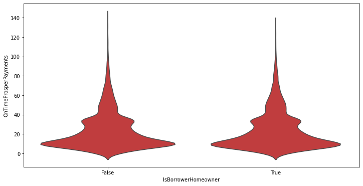

```python
# PLot distribution to check if isborrowerhomeowner affects ontime payments
plt.figure(figsize = [12, 6])
sb.violinplot(data=df, x='IsBorrowerHomeowner', y='OnTimeProsperPayments', color=base_color, inner=None);
```

### Talk about some of the relationships you observed in this part of the investigation. How did the feature(s) of interest vary with other features in the dataset?

> Based on the exploration done, it can be seen that those with verifiable income have high ProsperScore than those whose income can't be verified. Also, the ProsperScore of borrowers who are home owners is higher than those who are not. Lastly, most of the people that are employed are home ownwers. All these independent variables are great factors that influence the outcome of the dependent variable.

## Multivariate Exploration

```python
#Function to plot Multivariate Variables.
def multVariate(x,y,hue):
    plt.figure(figsize = [12, 5])
    ax = sb.pointplot(data = df, x = x, y = y, hue = hue,
                      dodge = True, linestyles = "")
    ax.set_xticklabels(ax.get_xticklabels(),rotation = 90);

#Function to plot Multivariate Variables.
def multVariate_II(x,y,hue):
    plt.figure(figsize = [12, 5])
    ax = sb.stripplot(data = df, x = x, y = y, hue = hue,
                      dodge = True, order=None, size = 2, jitter = 0.35 )
    x = x.replace("_"," ") # replace _ with space
    y = x.replace("_"," ")
    hue = x.replace("_"," ")
    #title
    plt.title(f''''Average {y} by {x} and {hue} '''.title(), fontsize =15, weight="bold")
    #Xlabel
    plt.xlabel(x.title(), fontsize = 12, weight = 'bold')
    plt.ylabel('frequency'.title(), fontsize = 12, weight = 'bold')

    #despine
    sb.despine()
```

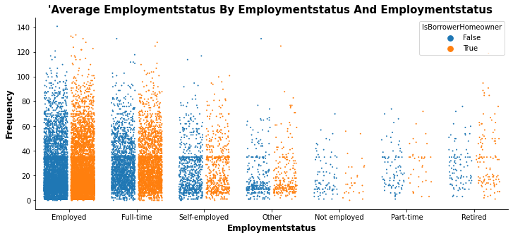

```python
# plot distribution to see the relationship between EmploymentStatus, ProsperScore and IsBorrowerHomeowner
multVariate_II('EmploymentStatus','OnTimeProsperPayments','IsBorrowerHomeowner' );
```

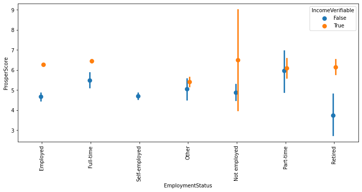

```python
multVariate('EmploymentStatus','ProsperScore','IncomeVerifiable' );
```

### Were there any interesting or surprising interactions between features?

> Yes, it can be seen from the point plot above that those there are not employed but have verifiable source of income have high prosper score.